# Agro932_HW2

Mason Lien

4/11/2022

Levering the Rodene et al., 2022 UAV dataset as we used in lab11 to test a hypothesis regarding the relationship between heritability and fitness (approximately equal to yield in an agriculture setting. In this case, canopy coverage on different dates can be considered as a proxy to reflect different levels of fitness):

1. Use the Github repo from homoework1 to host your homework2. If you don’t have the access to your homework1 repo, it is acceptable to create a new repo to host homework2 only. However, the repo should be a light-weighted repo that is not supposed to be nested within some other repo. (10 pts)

The github repository for this homework can be found at the following: https://github.com/Mlien89/Agro932_HW2

2. According to the Rodene et al., 2022 paper, identify a number of dates as a proxy of different levels of fitness and clearly specify your hypothesis to test (i.e., early dates of canopy coverage are more related to fitness) and speculate a little bit why that should be the case with or without citations. (20 pts)

```r
#load necessary packages and data from lab11

library(tidyr)
library(dplyr)
library(broom)
library(ggplot2)
library(ggpmisc)
df <- read.csv("C:/Users/u942451/OneDrive - University of Nebraska-Lincoln/school/PhD/2022-agro932-lab/data/ppj220030-sup-0002-tables1.csv")

#view frequency of days and number of observations
table(df$date)
```

```
##
## Aug12 Aug14 Aug16 Aug20 Aug22 Aug23 Aug26 Aug30 July6 Sept1 Sept3 Sept5
##   878   878   878   878   878   878   877   878   878   878   878   878
```

```r
#add replication
df$Rep <- "Rep2"
df[df$Row < 3000,] $Rep <- "Rep1"

#view first part of data frame
head(df)
```

```
##    Row   Row.Numbers Genotype   Pedigree Treatment  date Canopy_Coverage  Rep
## 1 1001 1001 and 1002     A641 Ames 19311  Nitrogen July6       29.747379 Rep1
## 2 1001 1001 and 1002     A641 Ames 19311  Nitrogen Aug23       15.537977 Rep1
## 3 1001 1001 and 1002     A641 Ames 19311  Nitrogen Sept1       15.189726 Rep1
## 4 1001 1001 and 1002     A641 Ames 19311  Nitrogen Aug22       19.037283 Rep1
## 5 1001 1001 and 1002     A641 Ames 19311  Nitrogen Aug12        9.793073 Rep1
## 6 1001 1001 and 1002     A641 Ames 19311  Nitrogen Aug26       21.378869 Rep1
```

3. Following the basic steps to estimate genetic variances (VA for the inbred population) and clearly interpret the ANOVA table and variance components in terms of the covariances between relatives. Show results for one date as an example. (50 pts)

the following linear equation applies to the produced ANOVAs for this assignment.

$p_{ijk} = \mu + g_i + t_i + g_i x t_i + r_k + e_{ijk}$,

where $p_{ijk}$ is the phenotype value of the ith genotype evaluated in the jth treatment with the kth rep, $g_i$ is the effect of the ith genotype, $t_i$ is the effect of the jth treatment (or environment), $g_i x t_j$ is the interaction effect of the ith genotype with the jth treatment, $r_k$ is the effect of the kth rep, and $e_{ijk}$ is the residual error. The $e_{ijk}$ have expectation to zero

the reference table below details the ANOVA for an inbred population.

| Source | df | Observed MS | E(MS) |
| --- | --- | --- | --- |
| Environment | $e-1=1$ |  |  |
| Replications/E | $r-1=1$ |  |  |
| Inbred lines | $n-1=232$ | $MS_{progeny}=275$ | $V_e + rV_{G \times E} + reV_{progeny}$ |
| Inbreds x E | $(n-1)(e-1)=224$ | $MS_{PE}=31$ | $V_e + rV_{G \times E}$ |
| pooled error | $(n-1)(r-1)e=419$ | $MS_{error}=32$ | $V_e$ |

- Inbred lines: $V_{progeny} = V_A$
  - $V_{progeny} = V_A = \frac{MS_{progeny} - MS_{PE}}{re} = \frac{275 -31}{2 \times 2} = 61$

–

let’s calculate and summarize ANOVA’s for all dates and store in a single data frame for later use.

```r
#create a dataframe with the summaries of all of the anovas for all of the dates for canopy coverage

summaries <- df %>% group_by(date) %>% do(tidy(aov(Canopy_Coverage ~ Genotype + Treatment + Genotype:Treatment + Rep, data = .)))

#lets look at the anova for Aug12

summaries[summaries$date == "Aug12",]
```

```
## # A tibble: 5 x 7
## # Groups:   date [1]
##   date  term                  df   sumsq meansq statistic    p.value
##   <chr> <chr>              <dbl>   <dbl>  <dbl>     <dbl>      <dbl>
## 1 Aug12 Genotype             232 336570. 1451.      16.6   7.01e-127
## 2 Aug12 Treatment              1   1581. 1581.      18.1   2.58e-  5
## 3 Aug12 Rep                    1   2096. 2096.      24.0   1.37e-  6
## 4 Aug12 Genotype:Treatment   224  20498.   91.5      1.05  3.39e-  1
## 5 Aug12 Residuals            419  36578.   87.3     NA    NA
```

# $h^2$ for Canopy Coverage

The $h^2$ on a plot-mean basis can be estimated as

$$\begin{align*}
h^2 & = \frac{V_{A}}{V_{A} + V_{\bar{Y}}} \\
& = \frac{V_{A}}{V_{A} + V_{G \times E}/e + V_{e}/(re)} \\
& = \frac{61}{61 + 31/4} = 0.89 \\
\end{align*}$$

let’s calculate narrow-sense heritability for each day and store in a table for visualization

```r
#store unique dates to loop through and calcualte heritability
dates <- as.character(unique(summaries$date))

#create list to store dataframes
h2_list <- list()

#loop to calculate h^2
for (i in dates){
  tmp <- summaries[summaries$date == i,]
  VA <- (tmp[1,5] - tmp[4,5])/(2*2)
  VP <- (tmp[4,5])/((length(unique(df$Rep)))*length(unique(df$Treatment)))
  h2 <- VA/(VA + (tmp[4,5])/((length(unique(df$Rep)))*length(unique(df$Treatment))))
  h2_list[[i]] <- cbind(i, h2)
}

#combine into single data frame
h2_df <- do.call("rbind", h2_list)
names(h2_df) <- c("date", "heritability")

#order by date
order <- c("July6","Aug12","Aug14","Aug16","Aug20","Aug22","Aug23","Aug26","Aug30","Sept1","Sept3","Sept5")
h2_df <- h2_df[match(order, h2_df$date),]

#add column with ascending order to use for visualization
h2_df <- h2_df %>% mutate(day_number = 1:n())
```

4. Visualize (for example, a barplot with the x-axis showing the dates and the y-axis showing the h2), interpret your results, and report them in a reproducible manner. (20 pts)

We can now plot the heritability data for each date and see how the values change over time

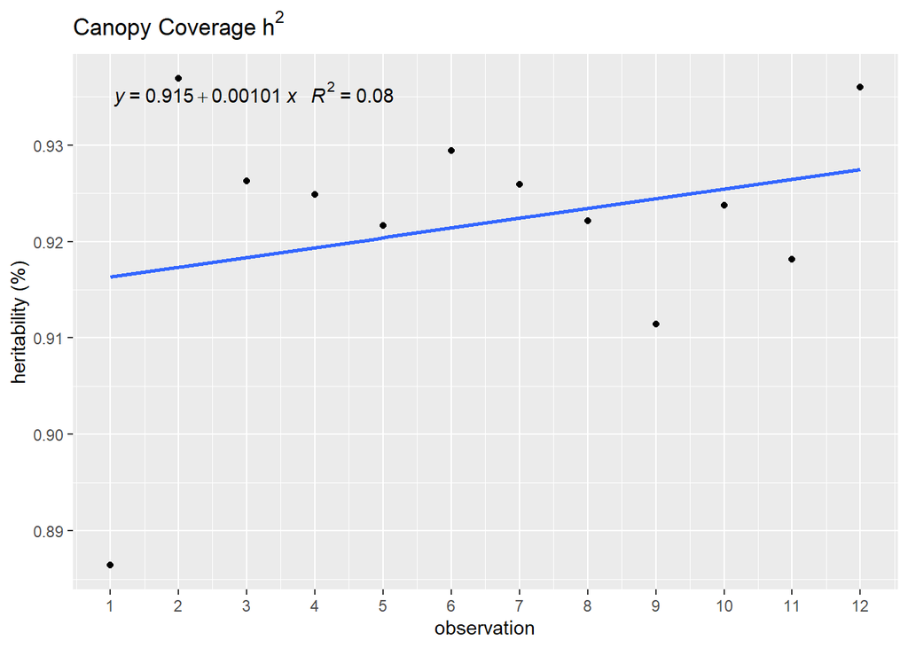

```r
ggplot(h2_df, aes(x = day_number, y = heritability))+
  geom_point() +
  scale_x_continuous(breaks = seq(1,12, by = 1)) +
  labs(title = "Canopy Coverage" ~h^2, x = "observation", y = "heritability (%)") +
  geom_smooth(method = "lm", se = F) +
  stat_poly_eq(formula = y ~ x,
                aes(label = paste(..eq.label.., ..rr.label.., sep = "~~~")),
                parse = TRUE)
```